# Factor Analysis

David Gerbing

## Data

Access the lessR data set called `datMach4` for the analysis of 351 people to the Mach IV scale. Read the optional variable labels. Including the item contents as variable labels means that the output of the confirmatory factor analysis contains the item content grouped by factor.

```r
d <- Read("Mach4", quiet=TRUE)
```

```r
l <- Read("Mach4_lbl", var_labels=TRUE)
```

```
##
## >>> Suggestions
## Recommended binary format for data files: feather
##   Create with Write(d, "your_file", format="feather")
## More details about your data, Enter:  details()  for d, or  details(name)
##
## Data Types
## ------------------------------------------------------------
## character: Non-numeric data values
## ------------------------------------------------------------
##
##     Variable                  Missing  Unique
##         Name     Type  Values  Values  Values   First and last values
## ------------------------------------------------------------------------------------------
##  1     label character     20       0      20   Never tell anyone the real reason you did something unless it is useful to do so ... Most people forget more easily the death of a parent than the loss of their property
## ------------------------------------------------------------------------------------------
```

Calculate the correlations and store in here in *mycor*, a data structure that contains the computed correlation matrix with the name R. Extract R from *mycor*.

```r
mycor <- cr(m01:m20)
```

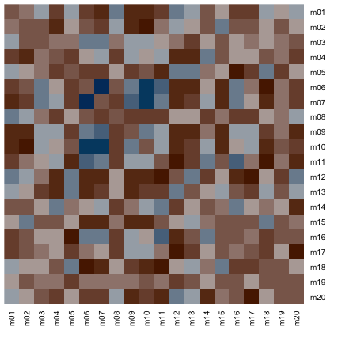

```r
R <- mycor$R
```

The correlation matrix for analysis is named R. The item (observed variable) correlation matrix is the numerical input into the confirmatory factor analysis.

## Exploratory Factor Analysis

```r
efa(R, n_factors=4)
```

[output not shown]

## Confirmatory Factor Analysis

The confirmatory factor analysis is of multiple-indicator measurement scales, that is, each item (observed variable) is assigned to only one factor. Solution method is centroid factor analysis.

Specify the measurement model for the analysis in Lavaan notation. Define four factors: Deceit, Trust, Cynicism, and Flattery.

```r
MeasModel <-
"
   Deceit =~ m07 + m06 + m10 + m09
   Trust =~ m12 + m05 + m13 + m01
   Cynicism =~ m11 + m16 + m04
   Flattery =~ m15 + m02
"
```

Do the confirmatory factor analysis of 4-factor solution of Mach IV scale, Hunter, Gerbing and Boster (1982). By default output goes to the console, or, can store the output into an object, here *cfa_out*, which can then be displayed as a whole, or piecemeal.

The abbreviation for `corCFA()` is `cfa()`.

```r
cfa_out <- cfa(MeasModel, R)
```

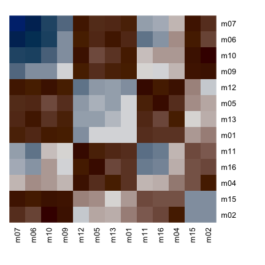

```r
cfa_out
```

```
##   FACTOR / SCALE COMPOSITION
##
## F1
## ------------------------------
## m07: There is no excuse for lying to someone else
## m06: Honesty is the best policy in all cases
## m10: When you ask someone to do something for you, it is best to give the real reasons for wanting
##      it rather than giving reasons which carry more weight
## m09: All in all, it is better to be humble and honest than to be important and dishonest
##
## F2
## ------------------------------
## m12: Anyone who completely trusts anyone else is asking for trouble
## m05: It is safest to assume that all people have a vicious streak and it will come out when they
##      are given a chance
## m13: The biggest difference between most criminals and other people is that the criminals are
##      stupid enough to get caught
## m01: Never tell anyone the real reason you did something unless it is useful to do so
##
## F3
## ------------------------------
## m11: Most people who get ahead in the world lead clean, moral lives
## m16: It is possible to be good in all respects
## m04: Most people are basically good and kind
##
## F4
## ------------------------------
## m15: It is wise to flatter important people
## m02: The best way to handle people is to tell them what they want to hear
##
##   RELIABILITY ANALYSIS
##
##  Scale   Alpha    Omega
## -----------------------
##    F1    0.691    0.701
##    F2    0.515    0.517
##    F3    0.402    0.421
##    F4    0.400    0.400
##
##   SOLUTION
```

[output cut: 101 more lines]

```
##    Cynicism =~ m11 + m16 + m04
##    Flattery =~ m15 + m02
## "
##
## library(lavaan)
## fit <- lavaan::cfa(MeasModel, data=d, std.ov=TRUE, std.lv=TRUE)
## summary(fit, fit.measures=TRUE)
##
## --------
## The preceding code fits the model from data frame:  d
## To access the correlation matrix directly without the data
##   replace the parameter  data  with the parameters
##         sample.cov  and  sample.nobs
##   These names refer to the name of the input correlation matrix and sample size
##
```

Or, view pieces. See the names of all the output components. The output includes:

- Heat map: Ordered correlation matrix, items within factors
- Item content: Items within factors
- Reliability analysis: Coefficient alpha and omega
- Solution: Factor pattern coefficients, indicator diagnostics
- Residual matrix: Items within factors
- Item Diagnostics: Sum of squares and average sum of squares by item
- Lavaan code: Run the model in Lavaan for maximum likelihood solution

```r
names(cfa_out)
```

```
##  [1] "call"                "out_title_scales"    "out_labels"          "out_title_rel"       "out_reliability"
##  [6] "out_title_solution"  "out_indicators"      "out_solution"        "out_title_residuals" "out_residuals"
## [11] "out_res_stats"       "out_title_lavaan"    "out_lavaan"          "out_Rmd"             "ff.cor"
## [16] "if.cor"              "diag.cor"            "alpha"               "omega"               "pred"
## [21] "resid"
```

Here just view just the scale reliabilities.

```r
cfa_out$out_reliability
```

```
##  Scale   Alpha    Omega
## -----------------------
##    F1    0.691    0.701
##    F2    0.515    0.517
##    F3    0.402    0.421
##    F4    0.400    0.400
```

Can also just analysis item content, without the factor analysis.

```r
cfa(MeasModel, labels="only")
```

```
##
## F1
## ------------------------------
## m07: There is no excuse for lying to someone else
## m06: Honesty is the best policy in all cases
## m10: When you ask someone to do something for you, it is best to give the real reasons for wanting it rather than giving reasons which carry more weight
## m09: All in all, it is better to be humble and honest than to be important and dishonest
##
## F2
## ------------------------------
## m12: Anyone who completely trusts anyone else is asking for trouble
## m05: It is safest to assume that all people have a vicious streak and it will come out when they are given a chance
## m13: The biggest difference between most criminals and other people is that the criminals are stupid enough to get caught
## m01: Never tell anyone the real reason you did something unless it is useful to do so
##
## F3
## ------------------------------
## m11: Most people who get ahead in the world lead clean, moral lives
## m16: It is possible to be good in all respects
## m04: Most people are basically good and kind
##
## F4
## ------------------------------
## m15: It is wise to flatter important people
## m02: The best way to handle people is to tell them what they want to hear
##
```

Generate R Markdown instructions of the confirmation factor analysis with the option: `Rmd`. Output file in this example will be m4.Rmd, a simple text file that can be edited with any text editor including RStudio, from which it can be knit to generate dynamic output such as to a Word document.

```
c <- cfa(MeasModel, R, Rmd="m4")
```

## Re-order the Correlation Matrix

### Hierarchical Cluster Analysis

Re-order the correlation matrix and display its heat map according to a hierarchical cluster analysis, indicated by the default parameter of the `order` parameter, `hclust`. Default input correlation matrix is the *mycor* structure, from which *R* will be extracted automatically.

The optional `n_clusters` parameter indicates to display corresponding cluster membership according to the specified number of clusters from the hierarchical tree. Although a four-factor solution, choose five clusters to allow for a “garbage” cluster.

```r
corReorder(n_clusters=5)
```

```
##
##  5 Cluster Solution
## -------------------
## m01 m05 m08 m12 m13 m18 m20 m02 m15 m03 m06 m07 m09 m10 m04 m11 m14 m16 m17 m19
##   1   1   1   1   1   1   1   2   2   3   3   3   3   3   4   4   4   4   5   5
```

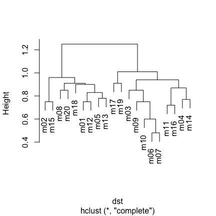

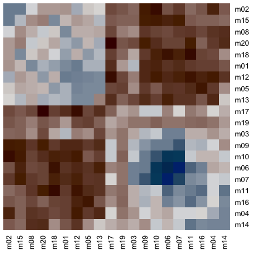

Use the `hclust_type` parameter to specify the type of cluster analysis provided by base R beyond the default of `"complete"`. Other possibilities include `"ward.D"`, `"ward.D2"`, `"single"`, `"average"`.

### Manual Reorder

The variables in the correlation matrix can be re-ordered manually, including sub-setting the matrix. Do so with the `vars` parameter, specifying the index (ordinal positioning) of each variable in the re-ordered matrix.

Here, subset six variables from the original correlation matrix. Specifying the `vars` parameter automatically sets `order` to `manual`, so no need to separately specify.

```r
R2 <- corReorder(vars=c(6,7,9,10,15,2))
```

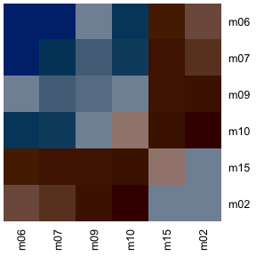

```r
R2
```

```
##       m06   m07   m09   m10   m15   m02
## m06  1.00  0.52  0.25  0.41 -0.15 -0.04
## m07  0.52  1.00  0.32  0.40 -0.17 -0.09
## m09  0.25  0.32  1.00  0.25 -0.17 -0.18
## m10  0.41  0.40  0.25  1.00 -0.18 -0.22
## m15 -0.15 -0.17 -0.17 -0.18  1.00  0.25
## m02 -0.04 -0.09 -0.18 -0.22  0.25  1.00
```

## Full Manual

Use the base R `help()` function to view the full manual for the factor analysis and correlation matrix functions. Simply enter a question mark followed by the name of the function.

```
?corCFA
?corEFA
?corScree
?corProp
?corRead
?corReflect
?corReorder
?Correlation
```